# Examen final de Introducción a R - Versión A

Bioinformática I — Versión A

Autor/a

Denisse Ximena Garcia Pacheco

## Instrucciones generales

**Duración: 120 minutos. Valor total: 100 puntos.**

El objetivo es reproducir dos figuras a partir de datos reales de mieles de abejas sin aguijón. Los conteos proporcionados corresponden únicamente a bacterias con asignación taxonómica a nivel de género. Se incluyen 17 muestras de dos especies de abejas.

Trabaja en tu proyecto de RStudio y utiliza este documento como [plantilla](https://github.com/CursosENESJuriquilla/Intro_to_R_Bioinfo_2027-1/raw/refs/heads/main/versionA.qmd). Sustituye el nombre del autor por el tuyo. Agrega tus bloques de código R ejecutables y tus respuestas en las secciones correspondientes. Conserva las rutas relativas y muestra el procedimiento completo. Las figuras de referencia son una guía: no es necesario reproducir exactamente la tipografía ni los tamaños.

## Importación y exploración (10 puntos)

Descarga y descomprime datos_A.zip. Importa con `readr` los archivos `conteos_genero_miel_bacterias.tsv` y `datos/metadata_miel_examen.csv`.

**Código**

```r
rm(list = ls())

library(readr)
library(tidyverse)
library(dplyr)
library(tidyr)
library(kableExtra)


conteos_raw <- read_tsv("datos_A/conteos_genero_miel_bacterias.tsv", show_col_types = FALSE)
metadata    <- read_csv("datos_A//metadata_miel_examen.csv", show_col_types = FALSE)
```

- Indica las dimensiones de ambas tablas y el número de muestras por especie de abeja.

**Código**

```r
dim.conteos <- dim(conteos_raw)
dim.meta <- dim(metadata)

cat("Las dimenciones (columnas  filas) de conteos_raw son:", dim.conteos, "\n")
```

```
Las dimenciones (columnas  filas) de conteos_raw son: 37128 3
```

**Código**

```r
cat("Las dimenciones (columnas  filas) de conteos_raw son:", dim.meta)
```

```
Las dimenciones (columnas  filas) de conteos_raw son: 17 14
```

**Código**

```r
# numero de  muestra por especie de abeja
 num_sp_abeja<- metadata %>%
  count(species, name = "n_muestras")

knitr::kable( num_sp_abeja,
              col.names = c("Especies", "Numero de muestras"))
```

| Especies | Numero de muestras |
| --- | --- |
| Melipona beecheii | 9 |
| Scaptotrigona mexicana | 8 |

- Identifica si existen valores faltantes en los metadatos e indica en qué variable o variables.

**Código**

```r
v.faltantes <- metadata %>%
  summarise(across(everything(), ~ sum(is.na(.)))) %>%
  pivot_longer(everything(), names_to = "variable", values_to = "n_na") %>%
  filter(n_na > 0)

knitr::kable( v.faltantes,
              col.names = c("Variable", "Numero de NAs"))
```

| Variable | Numero de NAs |
| --- | --- |
| Total_sugar | 2 |

## Integración y abundancia relativa (20 puntos)

Integra las dos tablas mediante el identificador `sample_id`. Calcula la abundancia relativa de cada género dentro de cada muestra, dividiendo su conteo entre la suma de los conteos de esa muestra. Conserva las abundancias como proporciones entre 0 y 1.

**Código**

```r
abundancia <- conteos_raw %>%
  mutate(conteo = replace_na(conteo, 0)) %>%
  inner_join(metadata, by = "sample_id") %>%
  group_by(sample_id) %>%
  mutate(
    total_muestra = sum(conteo, na.rm = TRUE),
    abundancia_rel = if_else(total_muestra > 0, conteo / total_muestra, 0)
  ) %>%
  ungroup()


tabla_abundancia <- abundancia %>%
  group_by(sample_id, species) %>%
  summarise(suma_abundancia = sum(abundancia_rel), .groups = "drop")

knitr::kable(tabla_abundancia,
              col.names = c("ID muestra", "Especie", "Abundancia (0, 1"),
             align = c("l", "c", "c"))
```

| ID muestra | Especie | Abundancia (0, 1 |
| --- | --- | --- |
| Melli_21 | Melipona beecheii | 1 |
| Melli_22 | Melipona beecheii | 1 |
| Melli_39 | Melipona beecheii | 1 |
| Melli_40 | Melipona beecheii | 1 |
| Melli_41 | Melipona beecheii | 1 |
| Melli_42 | Melipona beecheii | 1 |
| Melli_45 | Melipona beecheii | 1 |
| Melli_46 | Melipona beecheii | 1 |
| Melli_47 | Melipona beecheii | 1 |
| Scapto_23 | Scaptotrigona mexicana | 1 |
| Scapto_43 | Scaptotrigona mexicana | 1 |
| Scapto_51 | Scaptotrigona mexicana | 1 |
| Scapto_89 | Scaptotrigona mexicana | 1 |
| Scapto_90 | Scaptotrigona mexicana | 1 |
| Scapto_91 | Scaptotrigona mexicana | 1 |
| Scapto_92 | Scaptotrigona mexicana | 1 |
| Scapto_93 | Scaptotrigona mexicana | 1 |

## Figura 1: los 10 géneros más abundantes (25 puntos)

Calcula la abundancia relativa promedio de cada género considerando las 17 muestras, incluidos los conteos cero. Selecciona los diez con mayor promedio y reproduce la gráfica de barras horizontales ordenadas de mayor a menor. Muestra el eje de abundancia en porcentajes y agrega etiquetas apropiadas.

**Código**

```r
top10_generos <- abundancia %>%
  group_by(genero) %>%
  summarise(abundancia_media = mean(abundancia_rel, na.rm = TRUE), .groups = "drop") %>%
  slice_max(order_by = abundancia_media, n = 10) %>%
  mutate(genero = fct_reorder(genero, abundancia_media))


knitr::kable(top10_generos,
              col.names = c("Genero", "Abundancia relativa promedio"),
              digits = 3)
```

| Genero | Abundancia relativa promedio |
| --- | --- |
| Acetilactobacillus | 0.314 |
| Apilactobacillus | 0.065 |
| Nicoliella | 0.062 |
| Lactobacillus | 0.036 |
| Lentilactobacillus | 0.027 |
| Fructilactobacillus | 0.026 |
| Ligilactobacillus | 0.021 |
| Pediococcus | 0.020 |
| Tatumella | 0.020 |
| Limosilactobacillus | 0.019 |

**Código**

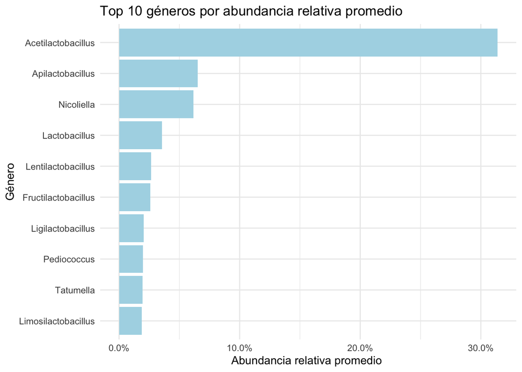

```r
ggplot(top10_generos, aes(x = abundancia_media, y = genero)) +
  geom_col(fill = "lightblue") +
  scale_x_continuous(labels = scales::percent_format(accuracy = 0.1)) +
  labs(
    title = "Top 10 géneros por abundancia relativa promedio",
    x = "Abundancia relativa promedio ",
    y = "Género"
  ) +
  theme_minimal()
```

## Figura 2: composición bacteriana por muestra (30 puntos)

Utiliza las abundancias relativas del apartado 2, **no solamente los diez taxones de la figura anterior**.

- Dentro de cada muestra, agrupa los géneros cuya abundancia relativa sea estrictamente menor al 5 % en la categoría `Géneros < 5%`. Suma las abundancias de esa categoría.
- Construye una gráfica de barras apiladas, una barra por muestra, separando las especies de abejas mediante facetas. Cada barra debe sumar 100 %.
- Utiliza la paleta proporcionada y coloca la leyenda debajo de la gráfica.

Paleta de referencia (puedes copiarla en un bloque de R) o puedes usar otra paleta de colores:

```r
genus_colors <- c(
  "Acetilactobacillus" = "#002868",
  "Apilactobacillus" = "#0077C2",
  "Lactobacillus" = "#66B2FF",
  "Nicoliella" = "#ADD8E1",
  "Pantoea" = "#008080",
  "Tatumella" = "#98FB98",
  "Fructobacillus" = "#007BA7",
  "Géneros < 5%" = "#778899"
)
```

**Código**

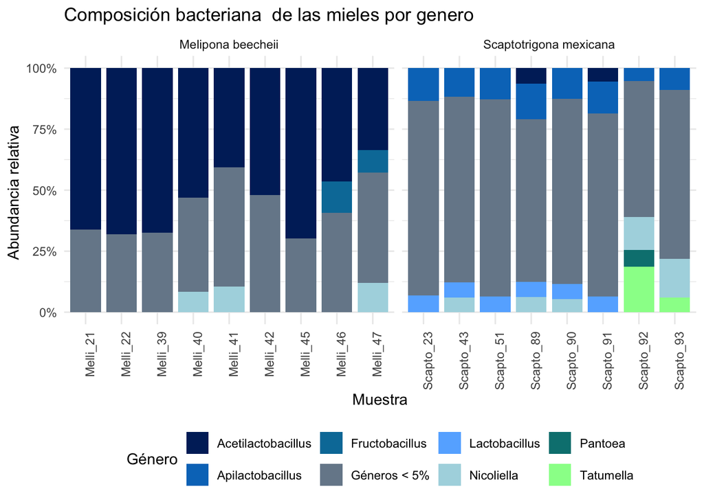

```r
genus_colors <- c(
  "Acetilactobacillus" = "#002868",
  "Apilactobacillus"   = "#0077C2",
  "Lactobacillus"      = "#66B2FF",
  "Nicoliella"         = "#ADD8E1",
  "Pantoea"            = "#008080",
  "Tatumella"          = "#98FB98",
  "Fructobacillus"     = "#007BA7",
  "Géneros < 5%"       = "#778899"
)

# Agrupar dentro de cada sample_id los géneros con abundancia relativa < 5%
fig2_df <- abundancia %>%
  mutate(
    categoria_genero = if_else(abundancia_rel < 0.05, "Géneros < 5%", genero)
  ) %>%
  group_by(sample_id, species, categoria_genero) %>%
  summarise(abundancia_rel = sum(abundancia_rel), .groups = "drop")

# Asegurar colores para cualquier taxón adicional que supere el 5%
faltantes_col <- setdiff(unique(fig2_df$categoria_genero), names(genus_colors))
if (length(faltantes_col) > 0) {
  paleta_extra <- scales::hue_pal()(length(faltantes_col))
  names(paleta_extra) <- faltantes_col
  genus_colors <- c(genus_colors, paleta_extra)
}


ggplot(fig2_df, aes(x = sample_id, y = abundancia_rel, fill = categoria_genero)) +
  geom_col(position = "fill", width = 0.85) +
  facet_grid(~ species, scales = "free_x", space = "free_x") +
  scale_y_continuous(labels = function(x) paste0(round(100 * x), "%")) +
  scale_fill_manual(values = genus_colors, drop = FALSE) +
  labs(
    title = "Composición bacteriana  de las mieles por genero ",
    x = "Muestra",
    y = "Abundancia relativa ",
    fill = "Género"
  ) +
  theme_minimal() +
  theme(
    legend.position = "bottom",
    axis.text.x = element_text(angle = 90, hjust = 1)
  )
```

## Interpretación (5 puntos)

Responde brevemente con base en tus resultados:

**1. ¿Cuál es el género con mayor abundancia relativa promedio?**

**2. ¿Qué diferencias o similitudes observas en la composición de las muestras de las dos especies de abejas?**

**Nota**: Todas las muestras pertenecen al mismo estudio y fueron procesadas con la misma metodología.

## Reporte reproducible y entrega (10 puntos)

Renderiza el documento a HTML y sube a tu repositorio de GitHub el archivo `.qmd`, el HTML generado y las carpetas de datos y figuras necesarias. Verifica que el HTML muestre tus resultados y gráficas sin necesidad de ejecutar el código nuevamente. Entrega el enlace al repositorio.

Si tienes un problema técnico con GitHub, conserva el `.qmd` y el HTML y notifícalo a la profesora antes de finalizar el examen.